# churn

### Einleitung

Viele Telekommunikationsunternehmen kämpfen mit einer Abwanderungsrate (Churn) von 15-25 % pro Monat. **Es ist deutlich günstiger, bestehende Kunden zu halten, als ständig neue zu gewinnen.**

Um gefährdete Kunden frühzeitig zu erkennen, müssen Unternehmen das Verhalten über Kanäle wie Kaufhistorien, Serviceanfragen und Social Media analysieren. So lassen sich gezielte Maßnahmen zur Stärkung der Kundenbindung ergreifen.

### Über den Datensatz

**IBM Sample Data Sets**

**Inhalt**  
Jede Zeile stellt einen Kunden dar, jede Spalte enthält Kundenattribute, die in den Spalten-Metadaten beschrieben sind.

Der Datensatz umfasst Informationen zu:

- **Kunden, die im letzten Monat gekündigt haben** – Spalte „Churn“
- **Gebuchte Dienste** – Telefon, mehrere Leitungen, Internet, Online-Sicherheit, Online-Backup, Geräteschutz, technischer Support sowie Streaming von TV und Filmen
- **Kundenkontodaten** – Vertragslaufzeit, Zahlungsmethode, papierlose Abrechnung, monatliche Gebühren und Gesamtkosten
- **Demografische Merkmale** – Geschlecht, Altersgruppe sowie Informationen zu Partnern und Angehörigen

```python
# libraries
import pandas as pd
import numpy as np
import seaborn as sns

import matplotlib.pyplot as plt
import plotly.express as px
import plotly.graph_objects as go
from plotly.subplots import make_subplots

from sklearn import metrics
from sklearn.metrics import classification_report
from sklearn.metrics import confusion_matrix
from sklearn.model_selection import train_test_split
from sklearn.preprocessing import StandardScaler
from sklearn.linear_model import LogisticRegression
from sklearn.ensemble import GradientBoostingClassifier
from sklearn.svm import SVC
from sklearn.tree import DecisionTreeClassifier
from sklearn.ensemble import RandomForestClassifier
from sklearn.naive_bayes import GaussianNB
from sklearn.neighbors import KNeighborsClassifier
from sklearn.svm import SVC
from sklearn.pipeline import Pipeline
from sklearn.metrics import accuracy_score, precision_score, recall_score, f1_score, roc_auc_score
from sklearn.ensemble import VotingClassifier
from imblearn.over_sampling import SMOTE

# Ignore warnings for cleaner output
import warnings
warnings.filterwarnings('ignore')
```

# 1) Setup & Data Preparation

```python
df = pd.read_csv('~/Desktop/Jup/Telco-Customer-Churn.csv')
```

```python
# each row represents a customer
# each column shows the customer's attributes
df.head()
```

|  | customerID | gender | SeniorCitizen | Partner | Dependents | tenure | PhoneService | MultipleLines | InternetService | OnlineSecurity | ... | DeviceProtection | TechSupport | StreamingTV | StreamingMovies | Contract | PaperlessBilling | PaymentMethod | MonthlyCharges | TotalCharges | Churn |
| --- | --- | --- | --- | --- | --- | --- | --- | --- | --- | --- | --- | --- | --- | --- | --- | --- | --- | --- | --- | --- | --- |
| 0 | 7590-VHVEG | Female | 0 | Yes | No | 1 | No | No phone service | DSL | No | ... | No | No | No | No | Month-to-month | Yes | Electronic check | 29.85 | 29.85 | No |
| 1 | 5575-GNVDE | Male | 0 | No | No | 34 | Yes | No | DSL | Yes | ... | Yes | No | No | No | One year | No | Mailed check | 56.95 | 1889.5 | No |
| 2 | 3668-QPYBK | Male | 0 | No | No | 2 | Yes | No | DSL | Yes | ... | No | No | No | No | Month-to-month | Yes | Mailed check | 53.85 | 108.15 | Yes |
| 3 | 7795-CFOCW | Male | 0 | No | No | 45 | No | No phone service | DSL | Yes | ... | Yes | Yes | No | No | One year | No | Bank transfer (automatic) | 42.30 | 1840.75 | No |
| 4 | 9237-HQITU | Female | 0 | No | No | 2 | Yes | No | Fiber optic | No | ... | No | No | No | No | Month-to-month | Yes | Electronic check | 70.70 | 151.65 | Yes |

5 rows × 21 columns

```python
df.shape
```

```
(7043, 21)
```

```python
# Display basic information about the dataset
print("\nDataset Info:")
df.info()
```

```
Dataset Info:
<class 'pandas.core.frame.DataFrame'>
RangeIndex: 7043 entries, 0 to 7042
Data columns (total 21 columns):
 #   Column            Non-Null Count  Dtype
---  ------            --------------  -----
 0   customerID        7043 non-null   object
 1   gender            7043 non-null   object
 2   SeniorCitizen     7043 non-null   int64
 3   Partner           7043 non-null   object
 4   Dependents        7043 non-null   object
 5   tenure            7043 non-null   int64
 6   PhoneService      7043 non-null   object
 7   MultipleLines     7043 non-null   object
 8   InternetService   7043 non-null   object
 9   OnlineSecurity    7043 non-null   object
 10  OnlineBackup      7043 non-null   object
 11  DeviceProtection  7043 non-null   object
 12  TechSupport       7043 non-null   object
 13  StreamingTV       7043 non-null   object
 14  StreamingMovies   7043 non-null   object
 15  Contract          7043 non-null   object
 16  PaperlessBilling  7043 non-null   object
 17  PaymentMethod     7043 non-null   object
 18  MonthlyCharges    7043 non-null   float64
 19  TotalCharges      7043 non-null   object
 20  Churn             7043 non-null   object
dtypes: float64(1), int64(2), object(18)
memory usage: 1.1+ MB
```

```python
df.dtypes
# It's noticeable that TotalCharges is stored as object type -> need to convert to float
```

```
customerID           object
gender               object
SeniorCitizen         int64
Partner              object
Dependents           object
tenure                int64
PhoneService         object
MultipleLines        object
InternetService      object
OnlineSecurity       object
OnlineBackup         object
DeviceProtection     object
TechSupport          object
StreamingTV          object
StreamingMovies      object
Contract             object
PaperlessBilling     object
PaymentMethod        object
MonthlyCharges      float64
TotalCharges         object
Churn                object
dtype: object
```

```python
# Print the total number of rows in the dataframe
print('index_size', df.index.size)
# Check for missing values
print("\nMissing Values:")
# Count number of NaN values in each column
print('is NaN', df.isna().sum())
# Count total number of duplicate rows
print('duplicated', df.duplicated().sum())
```

```
index_size 7043

Missing Values:
is NaN customerID          0
gender              0
SeniorCitizen       0
Partner             0
Dependents          0
tenure              0
PhoneService        0
MultipleLines       0
InternetService     0
OnlineSecurity      0
OnlineBackup        0
DeviceProtection    0
TechSupport         0
StreamingTV         0
StreamingMovies     0
Contract            0
PaperlessBilling    0
PaymentMethod       0
MonthlyCharges      0
TotalCharges        0
Churn               0
dtype: int64
duplicated 0
```

```python
# Change data type of TotalCharges column to numeric
# 'errors=coerce' will convert invalid parsing to NaN values
df['TotalCharges'] = pd.to_numeric(df.TotalCharges, errors='coerce')
df.isnull().sum()
```

```
customerID           0
gender               0
SeniorCitizen        0
Partner              0
Dependents           0
tenure               0
PhoneService         0
MultipleLines        0
InternetService      0
OnlineSecurity       0
OnlineBackup         0
DeviceProtection     0
TechSupport          0
StreamingTV          0
StreamingMovies      0
Contract             0
PaperlessBilling     0
PaymentMethod        0
MonthlyCharges       0
TotalCharges        11
Churn                0
dtype: int64
```

```python
# Check rows where TotalCharges column contains NaN values
df[np.isnan(df['TotalCharges'])]
```

|  | customerID | gender | SeniorCitizen | Partner | Dependents | tenure | PhoneService | MultipleLines | InternetService | OnlineSecurity | ... | DeviceProtection | TechSupport | StreamingTV | StreamingMovies | Contract | PaperlessBilling | PaymentMethod | MonthlyCharges | TotalCharges | Churn |
| --- | --- | --- | --- | --- | --- | --- | --- | --- | --- | --- | --- | --- | --- | --- | --- | --- | --- | --- | --- | --- | --- |
| 488 | 4472-LVYGI | Female | 0 | Yes | Yes | 0 | No | No phone service | DSL | Yes | ... | Yes | Yes | Yes | No | Two year | Yes | Bank transfer (automatic) | 52.55 | NaN | No |
| 753 | 3115-CZMZD | Male | 0 | No | Yes | 0 | Yes | No | No | No internet service | ... | No internet service | No internet service | No internet service | No internet service | Two year | No | Mailed check | 20.25 | NaN | No |
| 936 | 5709-LVOEQ | Female | 0 | Yes | Yes | 0 | Yes | No | DSL | Yes | ... | Yes | No | Yes | Yes | Two year | No | Mailed check | 80.85 | NaN | No |
| 1082 | 4367-NUYAO | Male | 0 | Yes | Yes | 0 | Yes | Yes | No | No internet service | ... | No internet service | No internet service | No internet service | No internet service | Two year | No | Mailed check | 25.75 | NaN | No |
| 1340 | 1371-DWPAZ | Female | 0 | Yes | Yes | 0 | No | No phone service | DSL | Yes | ... | Yes | Yes | Yes | No | Two year | No | Credit card (automatic) | 56.05 | NaN | No |
| 3331 | 7644-OMVMY | Male | 0 | Yes | Yes | 0 | Yes | No | No | No internet service | ... | No internet service | No internet service | No internet service | No internet service | Two year | No | Mailed check | 19.85 | NaN | No |
| 3826 | 3213-VVOLG | Male | 0 | Yes | Yes | 0 | Yes | Yes | No | No internet service | ... | No internet service | No internet service | No internet service | No internet service | Two year | No | Mailed check | 25.35 | NaN | No |
| 4380 | 2520-SGTTA | Female | 0 | Yes | Yes | 0 | Yes | No | No | No internet service | ... | No internet service | No internet service | No internet service | No internet service | Two year | No | Mailed check | 20.00 | NaN | No |
| 5218 | 2923-ARZLG | Male | 0 | Yes | Yes | 0 | Yes | No | No | No internet service | ... | No internet service | No internet service | No internet service | No internet service | One year | Yes | Mailed check | 19.70 | NaN | No |
| 6670 | 4075-WKNIU | Female | 0 | Yes | Yes | 0 | Yes | Yes | DSL | No | ... | Yes | Yes | Yes | No | Two year | No | Mailed check | 73.35 | NaN | No |
| 6754 | 2775-SEFEE | Male | 0 | No | Yes | 0 | Yes | Yes | DSL | Yes | ... | No | Yes | No | No | Two year | Yes | Bank transfer (automatic) | 61.90 | NaN | No |

11 rows × 21 columns

```python
# Replace missing values in 'TotalCharges' column with the median value
df['TotalCharges'].fillna(df['TotalCharges'].median(), inplace=True)
```

# 2) Exploratory Data Analysis (EDA)

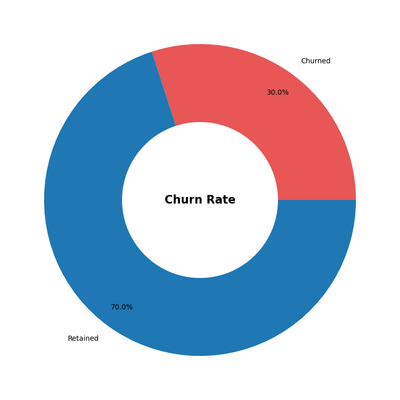

```python
# Visualization of customer churn rate
labels = ['Churned', 'Retained']
sizes = [30, 70]
colors = ['#e85656', '#1f77b4']

# Create a new figure and axis object
fig, ax = plt.subplots(figsize=(10, 10))

# donut chart
wedges, texts, autotexts = ax.pie(sizes,
                                 labels=labels,
                                 colors=colors,
                                 autopct='%1.1f%%',
                                 pctdistance=0.85,
                                 wedgeprops=dict(width=0.5))

# title text in the center of the donut chart
plt.text(0, 0, 'Churn Rate',
         horizontalalignment='center',
         verticalalignment='center',
         fontsize=16,
         fontweight='bold')

plt.show()
```

```python
# Remove customer IDs
churn_rate = df['Churn'].value_counts()
df2 = df.iloc[:,1:]

# Churn column to binary numeric values (1 for Yes, 0 for No)
df2['Churn'].replace(to_replace='Yes', value=1, inplace=True)
df2['Churn'].replace(to_replace='No',  value=0, inplace=True)

# categorical variables into dummy/indicator variables using one-hot encoding
df_dummies = pd.get_dummies(df2)
df_dummies.head()
```

|  | SeniorCitizen | tenure | MonthlyCharges | TotalCharges | Churn | gender_Female | gender_Male | Partner_No | Partner_Yes | Dependents_No | ... | StreamingMovies_Yes | Contract_Month-to-month | Contract_One year | Contract_Two year | PaperlessBilling_No | PaperlessBilling_Yes | PaymentMethod_Bank transfer (automatic) | PaymentMethod_Credit card (automatic) | PaymentMethod_Electronic check | PaymentMethod_Mailed check |
| --- | --- | --- | --- | --- | --- | --- | --- | --- | --- | --- | --- | --- | --- | --- | --- | --- | --- | --- | --- | --- | --- |
| 0 | 0 | 1 | 29.85 | 29.85 | 0 | True | False | False | True | True | ... | False | True | False | False | False | True | False | False | True | False |
| 1 | 0 | 34 | 56.95 | 1889.50 | 0 | False | True | True | False | True | ... | False | False | True | False | True | False | False | False | False | True |
| 2 | 0 | 2 | 53.85 | 108.15 | 1 | False | True | True | False | True | ... | False | True | False | False | False | True | False | False | False | True |
| 3 | 0 | 45 | 42.30 | 1840.75 | 0 | False | True | True | False | True | ... | False | False | True | False | True | False | True | False | False | False |
| 4 | 0 | 2 | 70.70 | 151.65 | 1 | True | False | True | False | True | ... | False | True | False | False | False | True | False | False | True | False |

5 rows × 46 columns

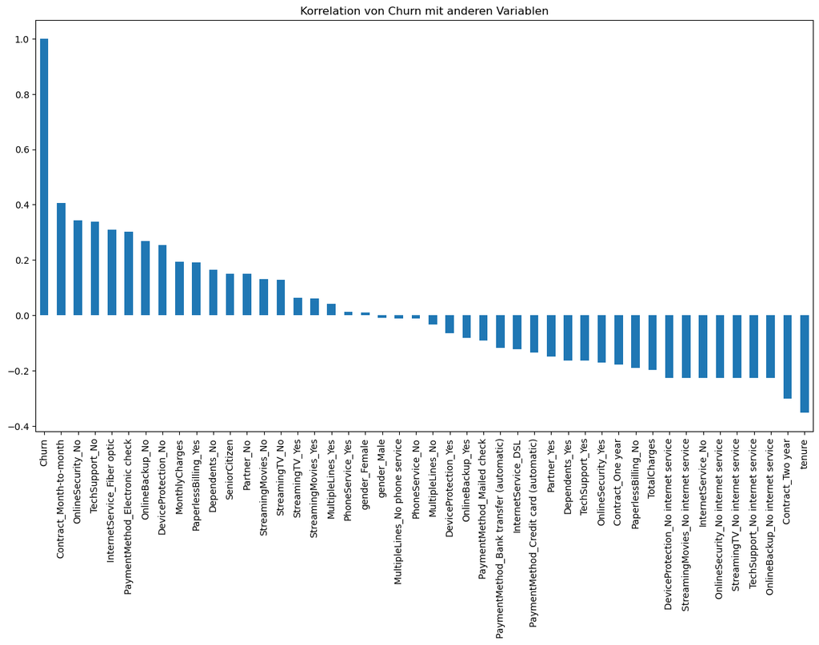

```python
# Correlation of "Churn" with other variables:
plt.figure(figsize=(15,8))
plt.title('Korrelation von Churn mit anderen Variablen')
df_dummies.corr()['Churn'].sort_values(ascending = False).plot(kind='bar')
```

Monatsverträge, das Fehlen von Online-Sicherheit und technischer Unterstützung scheinen positiv mit der Abwanderung (Churn) zu korrelieren. Im Gegensatz dazu scheinen längere Vertragslaufzeiten und Zweijahresverträge negativ mit der Abwanderung zu korrelieren.

Interessanterweise scheinen Dienstleistungen wie Online-Sicherheit, Streaming-TV, Online-Backup und technische Unterstützung, die ohne Internetverbindung angeboten werden, negativ mit der Abwanderung in Beziehung zu stehen.

Wir werden die Muster für die oben genannten Korrelationen im Folgenden näher untersuchen, bevor wir uns mit der Modellierung und der Identifizierung der wichtigen Variablen befassen.

```python
# categorical features by dropping non-categorical columns
features = df.columns.drop(['customerID', 'Churn', 'TotalCharges', 'tenure', 'MonthlyCharges'])
churn_distribution = []

# percentage distribution of churn values for each categorical feature
for feature in features:
    churn_counts = pd.crosstab(df[feature], df['Churn'], normalize='index') * 100
    churn_distribution.append(churn_counts)

# combine all contingency tables into one DataFrame with feature names as keys
churn_distribution_df = pd.concat(churn_distribution, keys=features)
churn_distribution_df.columns = ['No Churn (%)', 'Yes Churn (%)']

print(churn_distribution_df)
```

```
                                            No Churn (%)  Yes Churn (%)
gender           Female                        73.079128      26.920872
                 Male                          73.839662      26.160338
SeniorCitizen    0                             76.393832      23.606168
                 1                             58.318739      41.681261
Partner          No                            67.042021      32.957979
                 Yes                           80.335097      19.664903
Dependents       No                            68.720860      31.279140
                 Yes                           84.549763      15.450237
PhoneService     No                            75.073314      24.926686
                 Yes                           73.290363      26.709637
MultipleLines    No                            74.955752      25.044248
                 No phone service              75.073314      24.926686
                 Yes                           71.390104      28.609896
InternetService  DSL                           81.040892      18.959108
                 Fiber optic                   58.107235      41.892765
                 No                            92.595020       7.404980
OnlineSecurity   No                            58.233276      41.766724
                 No internet service           92.595020       7.404980
                 Yes                           85.388806      14.611194
OnlineBackup     No                            60.071244      39.928756
                 No internet service           92.595020       7.404980
                 Yes                           78.468506      21.531494
DeviceProtection No                            60.872375      39.127625
                 No internet service           92.595020       7.404980
                 Yes                           77.497936      22.502064
TechSupport      No                            58.364526      41.635474
                 No internet service           92.595020       7.404980
                 Yes                           84.833659      15.166341
StreamingTV      No                            66.476868      33.523132
                 No internet service           92.595020       7.404980
                 Yes                           69.929812      30.070188
StreamingMovies  No                            66.319569      33.680431
                 No internet service           92.595020       7.404980
                 Yes                           70.058565      29.941435
Contract         Month-to-month                57.290323      42.709677
                 One year                      88.730482      11.269518
                 Two year                      97.168142       2.831858
PaperlessBilling No                            83.669916      16.330084
                 Yes                           66.434908      33.565092
PaymentMethod    Bank transfer (automatic)     83.290155      16.709845
                 Credit card (automatic)       84.756899      15.243101
                 Electronic check              54.714588      45.285412
                 Mailed check                  80.893300      19.106700
```

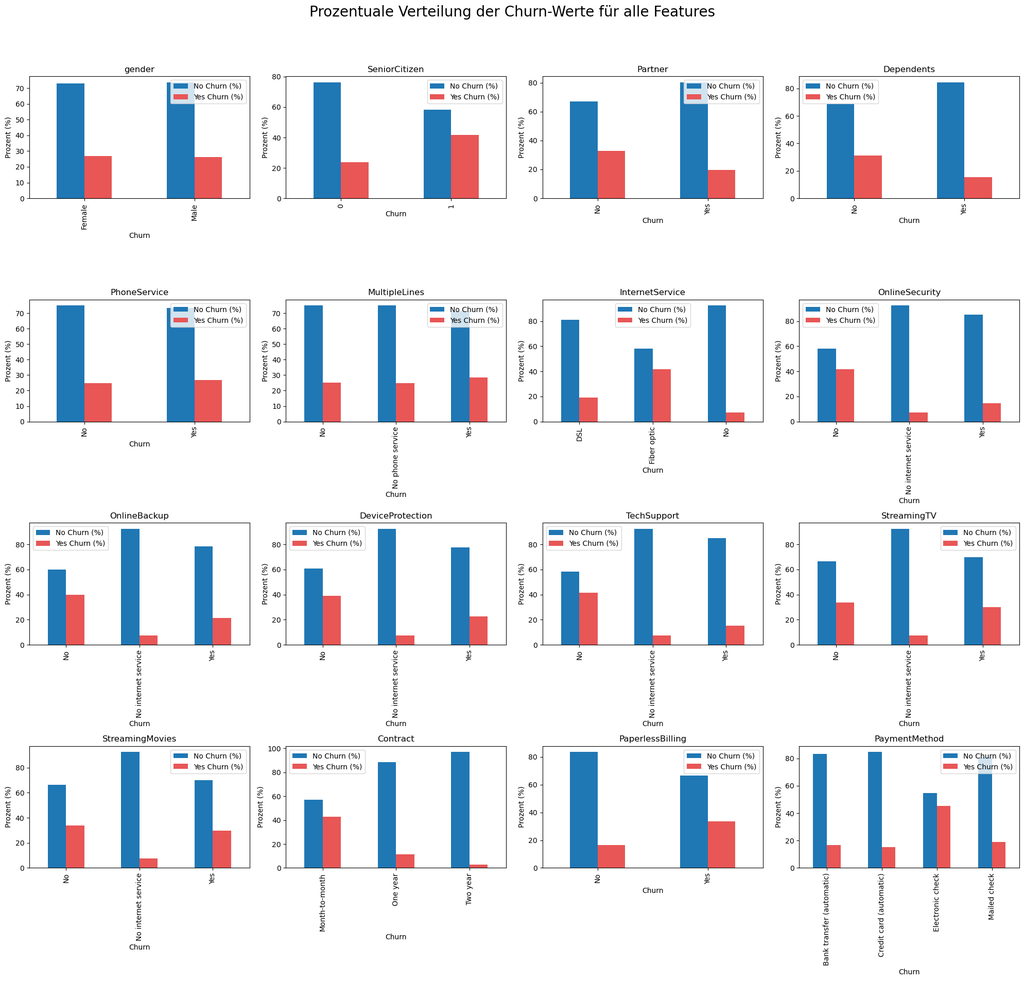

```python
# Visualization of the percentage distribution of churn values for all cat-features
fig, axes = plt.subplots(nrows=4, ncols=4, figsize=(20, 20))
fig.suptitle('Prozentuale Verteilung der Churn-Werte für alle Features', fontsize=20)

# Create a 4x4 subplot grid
for i, feature in enumerate(features):
    row, col = divmod(i, 4)
    churn_distribution_df.loc[feature].plot(kind='bar', ax=axes[row, col], color=['#1f77b4', '#e85656'])
    axes[row, col].set_title(feature)
    axes[row, col].set_ylabel('Prozent (%)')
    axes[row, col].set_xlabel('Churn')

plt.tight_layout(rect=[0, 0.03, 1, 0.95])
plt.show()
```

### Beobachtung der numerischen Werte nach Churn

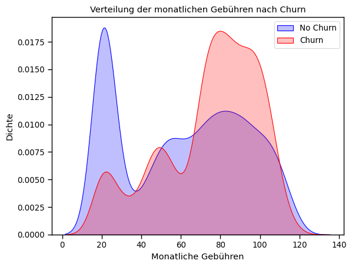

```python
sns.set_context("paper", font_scale=1.1)
ax = sns.kdeplot(df.MonthlyCharges[(df["Churn"] == 'No')],
                color="Blue", shade=True)
ax = sns.kdeplot(df.MonthlyCharges[(df["Churn"] == 'Yes')],
                ax=ax, color="Red", shade=True)
ax.legend(["No Churn", "Churn"], loc='upper right')
ax.set_ylabel('Dichte')
ax.set_xlabel('Monatliche Gebühren')
ax.set_title('Verteilung der monatlichen Gebühren nach Churn')
```

**monthly charges**: Kunden mit höheren monatlichen Gebühren neigen eher zur Kündigung. Dies könnte darauf hindeuten, dass Kostenbewusstsein ein wichtiger Faktor für Churn ist.

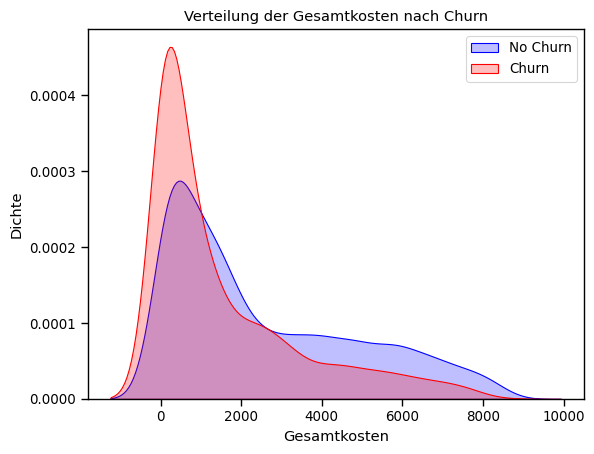

```python
ax = sns.kdeplot(df.TotalCharges[(df["Churn"] == 'No')],
                color="Blue", shade=True)
ax = sns.kdeplot(df.TotalCharges[(df["Churn"] == 'Yes')],
                ax=ax, color="Red", shade=True)
ax.legend(["No Churn", "Churn"], loc='upper right')
ax.set_ylabel('Dichte')
ax.set_xlabel('Gesamtkosten')
ax.set_title('Verteilung der Gesamtkosten nach Churn')
```

**total charges**: Es scheint, dass die Abwanderung höher ist, wenn die Gesamtkosten niedriger sind.

```python
fig = px.box(df, x='Churn', y = 'tenure')

# Update yaxis properties
fig.update_yaxes(title_text='Tenure (Months)', row=1, col=1)
# Update xaxis properties
fig.update_xaxes(title_text='Churn', row=1, col=1)

fig.update_layout(
    autosize=True,
    width=750,
    height=600,
    title_font=dict(size=14, family='Arial'),
    title='Laufzeit vs Churn',
    title_x=0.5,
    title_xanchor='center'
)

fig.show()
```

[interactive chart not shown]

**tenure**: Die Verteilung zeigt, dass Kunden mit kürzeren Vertragslaufzeiten (weniger als 12 Monate) eine höhere Abwanderungsrate haben, während Langzeitkunden stabiler sind.

# 3) Preprocessing Steps

#### Train-Test-Split

```python
# features and target variable
X = df_dummies.drop('Churn', axis=1)
y = df_dummies['Churn']

# Balance the dataset using SMOTE (Synthetic Minority Over-sampling Technique)
# Since Churn=Yes is less frequent than Churn=No, we need to balance the classes
smote = SMOTE(sampling_strategy=0.5)
X_resampled, y_resampled = smote.fit_resample(X, y)

# Split data into training (80%) and testing (20%) sets
X_train, X_test, y_train, y_test = train_test_split(X, y, test_size=0.2, random_state=42)

print(f'Train set size: {X_train.shape[0]}')
print(f'Test set size: {X_test.shape[0]}')
```

```
Train set size: 5634
Test set size: 1409
```

# 4) Build and Evaluate

#### KNN

```
KNN accuracy: 0.7963094393186657
              precision    recall  f1-score   support

           0       0.82      0.92      0.87      1036
           1       0.67      0.45      0.54       373

    accuracy                           0.80      1409
   macro avg       0.75      0.69      0.70      1409
weighted avg       0.78      0.80      0.78      1409
```

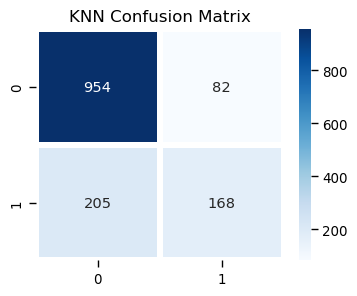

```python
knn_model = KNeighborsClassifier(n_neighbors = 11)
knn_model.fit(X_train,y_train)

predicted_y = knn_model.predict(X_test)

accuracy_knn = knn_model.score(X_test,y_test)
print("KNN accuracy:",accuracy_knn)
print(classification_report(y_test, predicted_y))
plt.figure(figsize=(4,3))
sns.heatmap(confusion_matrix(y_test, predicted_y),
                annot=True,fmt = "d",cmap='Blues',linewidths=3)

plt.title("KNN Confusion Matrix",fontsize=12)
plt.show()
```

#### RandomForest

```
0.8119233498935415
              precision    recall  f1-score   support

           0       0.84      0.93      0.88      1036
           1       0.71      0.49      0.58       373

    accuracy                           0.81      1409
   macro avg       0.77      0.71      0.73      1409
weighted avg       0.80      0.81      0.80      1409
```

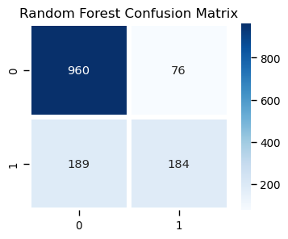

```python
model_rf = RandomForestClassifier(n_estimators=500, oob_score=True, n_jobs=-1,
                                   random_state=50, max_features="sqrt",
                                   max_leaf_nodes=30)
model_rf.fit(X_train, y_train)

prediction_test = model_rf.predict(X_test)

print(metrics.accuracy_score(y_test, prediction_test))
print(classification_report(y_test, prediction_test))
plt.figure(figsize=(4,3))
sns.heatmap(confusion_matrix(y_test, prediction_test),
                annot=True,fmt = "d",cmap='Blues',linewidths=3)

plt.title("Random Forest Confusion Matrix",fontsize=12)
plt.show()
```

#### Log. Regression

```
Logistic Regression accuracy: 0.8211497515968772
              precision    recall  f1-score   support

           0       0.86      0.90      0.88      1036
           1       0.69      0.60      0.64       373

    accuracy                           0.82      1409
   macro avg       0.77      0.75      0.76      1409
weighted avg       0.82      0.82      0.82      1409
```

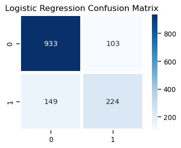

```python
model_rlog = LogisticRegression(max_iter=1000)
model_rlog.fit(X_train, y_train)

predicted_y = model_rlog.predict(X_test)

accuracy_rlog = model_rlog.score(X_test, y_test)
print("Logistic Regression accuracy:", accuracy_rlog)
print(classification_report(y_test, predicted_y))


plt.figure(figsize=(4,3))
sns.heatmap(confusion_matrix(y_test, predicted_y),
            annot=True, fmt="d", cmap='Blues', linewidths=3)
plt.title("Logistic Regression Confusion Matrix", fontsize=12)
plt.show()
```

#### Desicion Tree

```
Decision Tree accuracy: 0.7955997161107168
              precision    recall  f1-score   support

           0       0.81      0.94      0.87      1036
           1       0.71      0.39      0.50       373

    accuracy                           0.80      1409
   macro avg       0.76      0.67      0.69      1409
weighted avg       0.78      0.80      0.77      1409
```

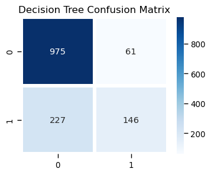

```python
model_dt = DecisionTreeClassifier(max_depth=3)
model_dt.fit(X_train, y_train)

predicted_y = model_dt.predict(X_test)

accuracy_dt = model_dt.score(X_test, y_test)
print("Decision Tree accuracy:", accuracy_dt)
print(classification_report(y_test, predicted_y))

plt.figure(figsize=(4,3))
sns.heatmap(confusion_matrix(y_test, predicted_y),
            annot=True, fmt="d", cmap='Blues', linewidths=3)
plt.title("Decision Tree Confusion Matrix", fontsize=12)
plt.show()
```

```
Ergebnisse der Modelle:
               Modell  Genauigkeit  Präzision    Recall  F1-Score   ROC-AUC
0                 KNN     0.796309   0.672000  0.450402  0.539326  0.809692
1        RandomForest     0.811923   0.707692  0.493298  0.581359  0.862673
2  LogisticRegression     0.821150   0.685015  0.600536  0.640000  0.862146
3        DecisionTree     0.795600   0.705314  0.391421  0.503448  0.828240
```

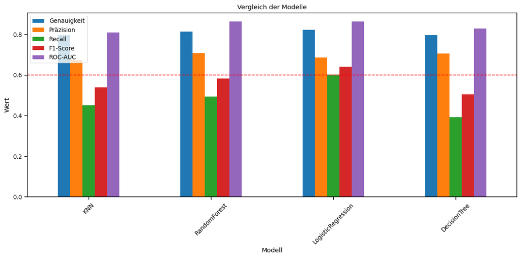

```python
# all models in comparison
models = {
    'KNN': knn_model,
    'RandomForest': model_rf,
    'LogisticRegression': model_rlog,
    'DecisionTree': model_dt,
}

results = []

for model_name, model in models.items():
    model.fit(X_train, y_train)

    predictions = model.predict(X_test)
    predictions_proba = model.predict_proba(X_test)[:, 1]  # Wahrscheinlichkeit für positive Klasse

    accuracy = accuracy_score(y_test, predictions)
    precision = precision_score(y_test, predictions)
    recall = recall_score(y_test, predictions)
    f1 = f1_score(y_test, predictions)
    roc_auc = roc_auc_score(y_test, predictions_proba)

    results.append({
        'Modell': model_name,
        'Genauigkeit': accuracy,
        'Präzision': precision,
        'Recall': recall,
        'F1-Score': f1,
        'ROC-AUC': roc_auc
    })

results_df = pd.DataFrame(results)
print("\nErgebnisse der Modelle:")
print(results_df)

results_df.set_index('Modell')[['Genauigkeit', 'Präzision', 'Recall', 'F1-Score', 'ROC-AUC']].plot(kind='bar', figsize=(12, 6))
plt.title('Vergleich der Modelle')
plt.ylabel('Wert')
plt.xticks(rotation=45)
plt.axhline(0.60, color='red', linestyle='--')
plt.legend(loc='upper left')
plt.tight_layout()
plt.show()
```

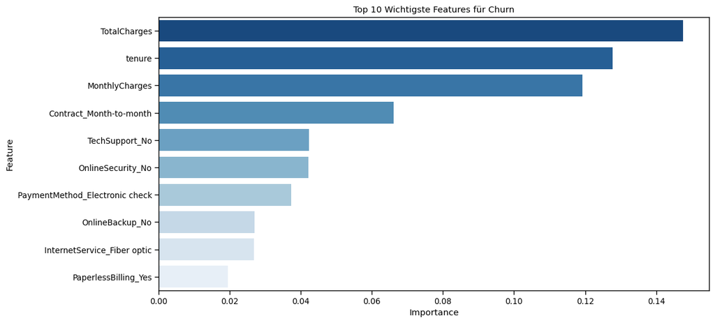

```python
# Feature Importance Analyse
importances = RandomForestClassifier().fit(X_resampled, y_resampled).feature_importances_
feature_importance_df = pd.DataFrame({'Feature': X_resampled.columns, 'Importance': importances})
feature_importance_df = feature_importance_df.sort_values(by='Importance', ascending=False)

# Visualization of Feature Importance
plt.figure(figsize=(12, 6))
sns.barplot(x='Importance', y='Feature', data=feature_importance_df.head(10), palette='Blues_r')
plt.title('Top 10 wichtigste Features für Churn')
plt.show()
```

# 5) Insights

Durch die Identifizierung der wichtigsten Merkmale, die zur Abwanderung führen, können wir gezielte Maßnahmen ergreifen, um die Kundenbindung zu stärken.

Einige der entscheidenden Faktoren, die wir entdeckt haben, sind:

**Monatliche Gebühren:** Höhere Gebühren korrelieren häufig mit einer erhöhten Abwanderungsrate. Dies deutet darauf hin, dass wettbewerbsfähige Preisgestaltungen entscheidend sind.

**Vertragslaufzeit:** Kunden mit längeren Vertragslaufzeiten zeigen eine geringere Abwanderungsneigung, was auf die Bedeutung von Loyalitätsprogrammen hinweist.

# 6) Handlunsgempfehlung

**Gezielte Kundenansprache**

- **Risikokunden identifizieren**: Merkmale wie „TotalCharges“, „tenure“ und „MonthlyCharges“ bieten wertvolle Insights, um potenzielle Abgangskandidaten frühzeitig zu erkennen.
- **Personalisierte Angebote**: Maßgeschneiderte Angebote stärken die Kundenbindung und reduzieren das Abgangsrisiko.

**Vertragsstrategie optimieren**

- **Einfache Vertragsoptionen**: Langfristige Verträge schaffen mehr Stabilität und erhöhen die Kundenbindung.
- **Boni für Verlängerungen**: Rabatte und zusätzliche Vorteile setzen Anreize für eine längere Vertragsbindung und stärken die Kundenloyalität.

**Technischen Support ausbauen**

- **Zufriedenheit steigern**: Ein effektiver Support begegnet gezielt Unsicherheiten bei „TechSupport_No“ und „OnlineSecurity_No“ und sorgt für zufriedene Kunden.
- **Proaktive Kommunikation**: Regelmäßige Updates und gezielte Supportangebote halten die Kunden informiert und schaffen Vertrauen.

**Zahlungsmethoden optimieren**

- **Zahlungsvielfalt erweitern**: Mehr Zahlungsmethoden schaffen Flexibilität und beseitigen Barrieren, insbesondere bei „PaymentMethod_Electronic check“.
- **Automatische Zahlungen fördern**: Mit gezielten Anreizen können automatische Zahlungen zum Standard werden, was für beide Seiten bequem ist.

**Zusatzservices pushen**

- **Mehrwert kommunizieren**: Die Vorteile von „OnlineBackup“ und „OnlineSecurity“ können das Gesamtpaket abrunden und den Kunden das Gefühl einer rundum sicheren Lösung vermitteln.
- **Neukunden gewinnen**: Durch attraktive Rabatte auf Zusatzservices kann zusätzlicher Umsatz generiert werden, während neue Kunden gleichzeitig gewonnen werden.

**Kundenzufriedenheit steigern**

- **Feedback regelmäßig einholen**: Kontinuierliche Umfragen helfen, die Kundenzufriedenheit zu messen und schnell auf Verbesserungsbedarfe zu reagieren.
- **Schnelle Reaktionszeiten**: Eine zügige Bearbeitung von Rückmeldungen stärkt das Vertrauen und fördert langfristige Kundenbeziehungen.